# lab4

## Lab 4: Working with 'real' data

```python
%matplotlib inline
import numpy as np
import matplotlib
import matplotlib.pyplot as plt
import scipy
from scipy import stats
import h5py
import statistics

#this sets the size of the plot to something useful
plt.rcParams["figure.figsize"] = (20,15)
```

```python
hf = h5py.File('gammaray_lab4.h5', 'r')
```

```python
hf.keys()
```

```
<KeysViewHDF5 ['data']>
```

```python
data = np.array(hf.get('data'))
```

```python
data[:,0]
```

```
array([9.40680016e+08, 3.15000000e+02, 4.50000000e+01, 1.00000000e+01])
```

```python
hf.close()
```

### Problem 1

Data from a gamma-ray satellite. Take in readings every 100 milliseconds, in an approximately 90 minute orbit. Virtually all data collected is background cosmic rays.

#### 1)

Make plots to generally explore the data, give a high level description of data features, comment on signal contamination, and how you plan on building the background pdf().

Provided data 'hf' contains 4 columns:

- time(in gps seconds)
- solar phase(in degrees) - position of sun relative to orbit
- earth longitude(in degrees) - giving position of spacecraft relative to the ground
- paricle counts

Plotting the entire data set will normally crash the kernel due to the sheer volume of data points, hence why I chose to plot only 1 in every hundred thousand data points. The first plot is the relationship between time in gps seconds and position of the sun relative to orbit in degrees.

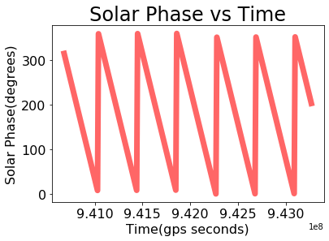

```python
fig, ax = plt.subplots(1, 1)

ax.plot(data[0,::100000], data[1,::100000],
       'r', lw=7, alpha=0.6)
plt.tick_params(labelsize = 16)
plt.title("Solar Phase vs Time"
          ,fontsize=24)
plt.xlabel("Time(gps seconds)", fontsize = 16)
plt.ylabel('Solar Phase(degrees)', fontsize = 16)
plt.show()
```

This shows us the relationships between time in gps seconds and the location of the satellite in degrees longitude. As seen here using the original ratio of one data point for every 100,000 creates a really condensed graph. This is because the satellite orbits the earth once every 90 minutes, which is considerably faster than the changing of the position of the sun relative to the orbit. Changing it to 1 in every million we can get a better visualization of the longitudinal values of the satellite. Once again this gives us a general understanding of the data, and discrete values cannot be depended on because we are taking 1 in every million points.

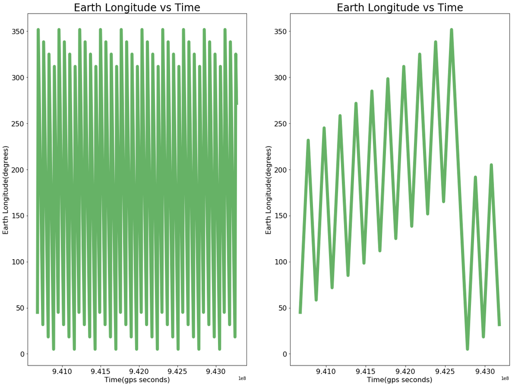

```python
plt.rcParams["figure.figsize"] = (20,15)

plt.subplot(1,2,1)
plt.title("Earth Longitude vs Time"
          ,fontsize=24)
plt.xlabel("Time(gps seconds)", fontsize = 16)
plt.ylabel('Earth Longitude(degrees)', fontsize = 16)
plt.tick_params(labelsize = 16)
plt.plot(data[0,::100000], data[2,::100000],
       'g', lw=7, alpha=0.6)

plt.subplot(1,2,2)
plt.title("Earth Longitude vs Time"
          ,fontsize=24)
plt.xlabel("Time(gps seconds)", fontsize = 16)
plt.ylabel('Earth Longitude(degrees)', fontsize = 16)
plt.tick_params(labelsize = 16)
plt.plot(data[0,::1000000], data[2,::1000000],
       'g', lw=7, alpha=0.6)

plt.show()
```

Analyzing the data we can see discrete peaks and valleys. This follows somewhat of an oscillatory motion. Most of the particles detected are just background cosmic rays, while the the deviations from the background have a possibility to be gamma-ray bursts.

Since this is a low earth orbit satellite, a lot of the particles detected are being blocked by the earth itself. Some causes of signal contamination is instrumentation malfunctioning, as well as the gamma-ray bursts being blocked from the sun and the moon.

Since we are describing the probability of a given number of events occurring in a fixed interval of time(particle count detection every 100 milliseconds), I believe a poisson distribution will be able to accurately describe the background of cosmic rays in our pdf.

By using every 100,000 data points sum and average, I was able to see a general oscillatory motion of the particle count(clear decreasing trend that resets). This gives some inclination that solar phase and longitudinal phase plays some role in determining the particle count observed.

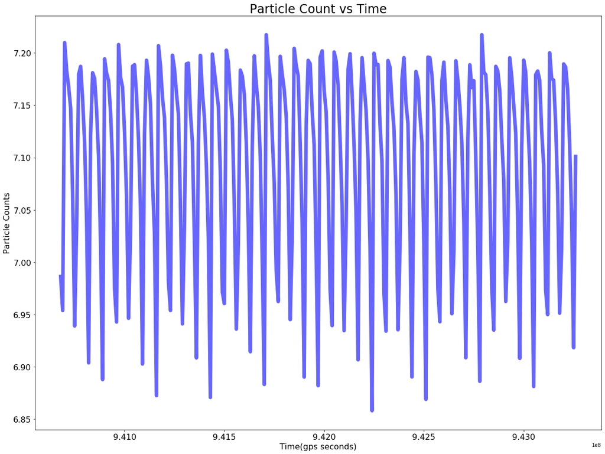

```python
fig, ax = plt.subplots(1, 1)

particleCount = []
count = 0
sum = 0
for i in range(len(data[3,:])):
    if count == 100000:
        count = 0
        val = sum / 100000
        sum = 0
        particleCount.append(val)
    else:
        count = count + 1
        sum = sum + data[3, i]

time = data[0,::100000]
time = time[:-1]
ax.plot(time, particleCount,
       'b', lw=7, alpha=0.6)
plt.tick_params(labelsize = 16)
plt.title("Particle Count vs Time"
          ,fontsize=24)
plt.xlabel("Time(gps seconds)", fontsize = 16)
plt.ylabel('Particle Counts', fontsize = 16)
plt.show()
```

The following shows the graph of the first 2000 points in the particle count data frame. As depicted, this is not a good means of exploring the data - the particle count looks random, and the graph does not show any general trend.

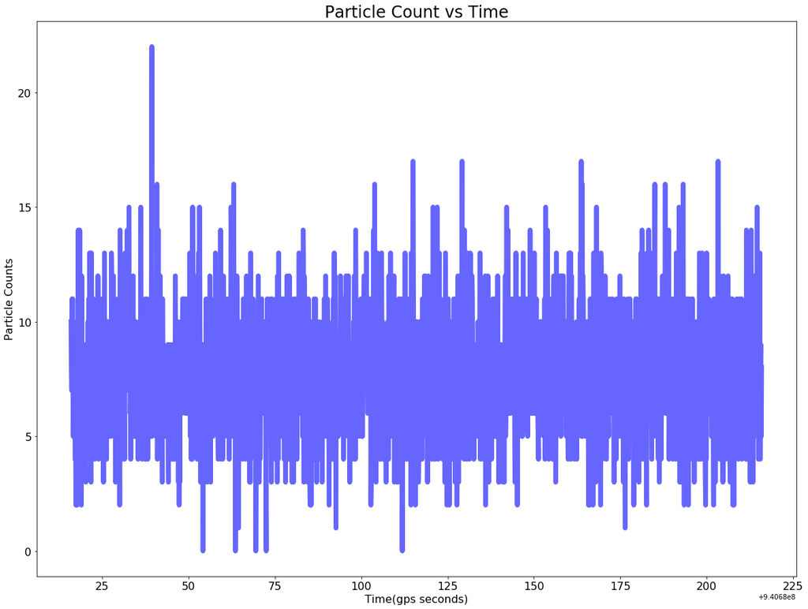

```python
fig, ax = plt.subplots(1, 1)
ax.plot(data[0,0:2000], data[3,0:2000],
       'b', lw=7, alpha=0.6)
plt.tick_params(labelsize = 16)
plt.title("Particle Count vs Time"
          ,fontsize=24)
plt.xlabel("Time(gps seconds)", fontsize = 16)
plt.ylabel('Particle Counts', fontsize = 16)
plt.show()
```

#### 2)

Find and describe background changes and inconsistencies.

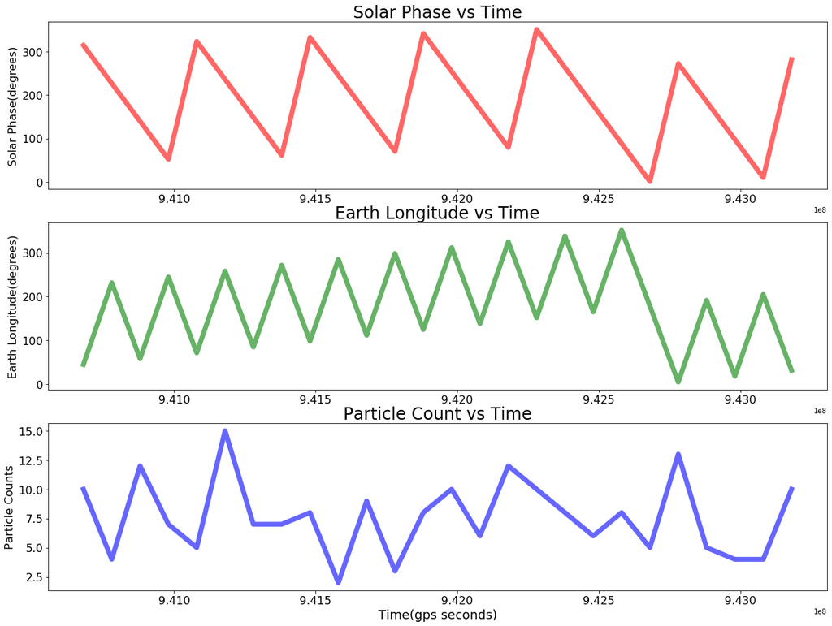

```python
plt.rcParams["figure.figsize"] = (20,15)

plt.subplot(3,1,1)
plt.title("Solar Phase vs Time"
          ,fontsize=24)
#plt.xlabel("Time(gps seconds)", fontsize = 16)
plt.ylabel('Solar Phase(degrees)', fontsize = 16)
plt.tick_params(labelsize = 16)
plt.plot(data[0,::1000000], data[1,::1000000],
       'r', lw=7, alpha=0.6)

plt.subplot(3,1,2)
plt.title("Earth Longitude vs Time"
          ,fontsize=24)
#plt.xlabel("Time(gps seconds)", fontsize = 16)
plt.ylabel('Earth Longitude(degrees)', fontsize = 16)
plt.tick_params(labelsize = 16)
plt.plot(data[0,::1000000], data[2,::1000000],
       'g', lw=7, alpha=0.6)

plt.subplot(3,1,3)
plt.tick_params(labelsize = 16)
plt.title("Particle Count vs Time"
          ,fontsize=24)
plt.xlabel("Time(gps seconds)", fontsize = 18)
plt.ylabel('Particle Counts', fontsize = 16)
plt.plot(data[0,::1000000], data[3,::1000000],
       'b', lw=7, alpha=0.6)

plt.show()
```

#### 3)

Create a model that includes time dependence and compare your model to the data.

I believe that a poisson distribution model does a decent job of approximating the background of our distribution because it is relatively consistent with the data around the mean, but as we move towards the edges of the distribution, the difference between the actual data and the model grows. This is indicative of a 5-sigma event occuring(e.g. seeing a gamma ray burst.)

[output not shown]

[figure not shown]

```python
mu = statistics.mean(data[3][::100000])
d_poisson = stats.poisson.rvs(mu, size = 26000000)
plt.tick_params(labelsize = 16)
plt.hist(d_poisson, 100, density=True, color='c')
plt.hist(data[3], 100, density=True, color='k')
plt.title("Particle Count Avg vs Poisson Comparison"
          ,fontsize=24)
#plt.xlabel("Time(gps seconds)", fontsize = 18)
#plt.ylabel('Particle Count Avg', fontsize = 16)
plt.yscale('log')
plt.show()
```

#### 4)

The background varies, what is the 5-sigma threshold for a GRB based on time.

By varying which part of the particle data frame I looked at, I was able to get different means for the particle count distribution. Although the mean happened to be different for the 3 different time frames selected, the difference happens to be so insignificant that the 5 sigma threshold for a GRB seems to collapse at 24.0 for all 3 cases.

```python
t1 = statistics.mean(data[3,0:100000])
print(t1)
t2 = statistics.mean(data[3,200000:400000])
print(t2)
t3 = statistics.mean(data[3,500000:900000])
print(t3)
sig5 = 1 - stats.norm.cdf(5)
print("Sig 5 probability: ", sig5)
sigt1 = stats.poisson.ppf(1-sig5, t1)
sigt2 = stats.poisson.ppf(1-sig5, t2)
sigt3 = stats.poisson.ppf(1-sig5, t3)
print(sigt1)
print(sigt2)
print(sigt3)
```

```
6.9863
7.196495
7.0462
Sig 5 probability:  2.866515719235352e-07
24.0
24.0
24.0
```

### Problem 2

#### 1)

Download the data

```python
hf = h5py.File('images.h5', 'r')
print(hf.keys())
data2 = np.array(hf.get('imagestack'))
print(np.shape(data2))
hf.close()
```

```
<KeysViewHDF5 ['image1', 'imagestack']>
(200, 200, 10)
```

#### 2)

Explore the data

The stack of 10 square images all appear to be of similar fashion, where the colorbar is indicative of the brightest stars seen. Inspecting the images it seems that they all have generally the same pattern of stars. Therefore, I believe the background is not time dependent. The brightness of stars varies drastically, but upon inspecting all 10 telescopic images I was not able to find any obvious signs of signal contamination. If contamination of the data were to occur I would guess it would be related to sensing a very faint star that is not actually there or misjudging the brightness of a bright star due to telescope calibrations. The data is indeed spatially consistent across all 10 photos, the stars seem to be in the same position in every iteration. I plan to calculate the background pdf by comparing the star brightness across all images.

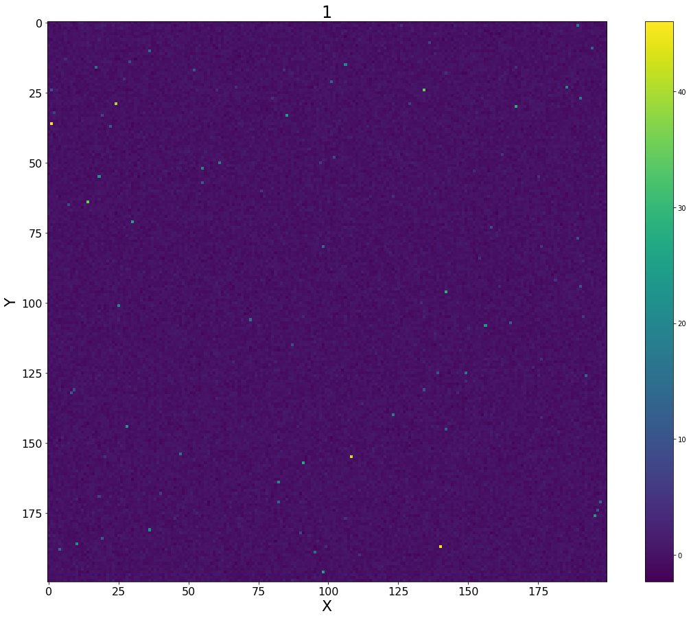

[output not shown]

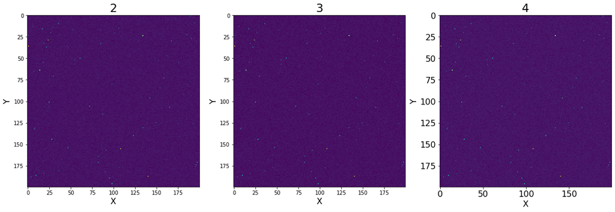

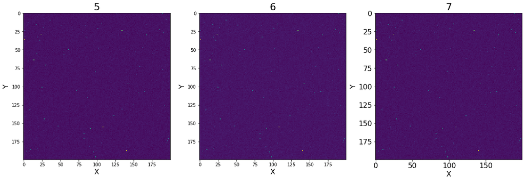

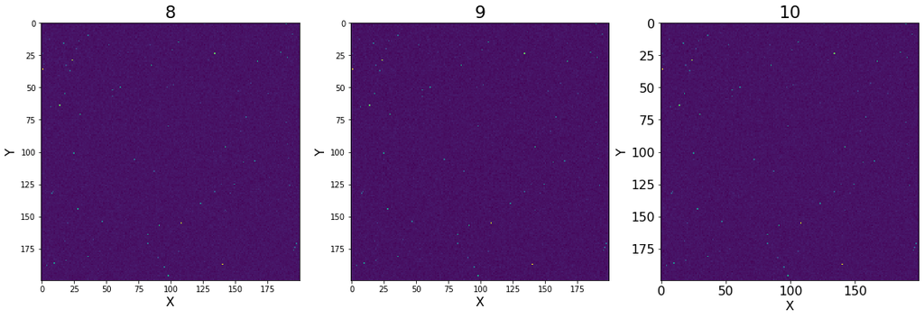

```python
plt.title('1', fontsize = 24)
plt.tick_params(labelsize = 16)
plt.xlabel('X', fontsize = 22)
plt.ylabel('Y', fontsize = 22)
plt.imshow(data2[:,:,0])
plt.colorbar()
plt.show()
data_remaining = data2[:,:,1:10]
for i in range(3):
    fig, ax = plt.subplots(1, 3)
    for j in range(3):
        ax[j].set_title((i*3) + j + 2, fontsize = 22)
        ax[j].set_xlabel('X', fontsize = 16)
        plt.tick_params(labelsize = 16)
        ax[j].set_ylabel('Y', fontsize = 16)
        ax[j].imshow(data_remaining[:,:,(i*3) + j])
```

#### 3)

Use your background distribution to find the transient stars.

In this particular case I am going to go under the assumption that the star data follows a normal distribution, and the transient star we are looking for is in the outliers of this distribution.

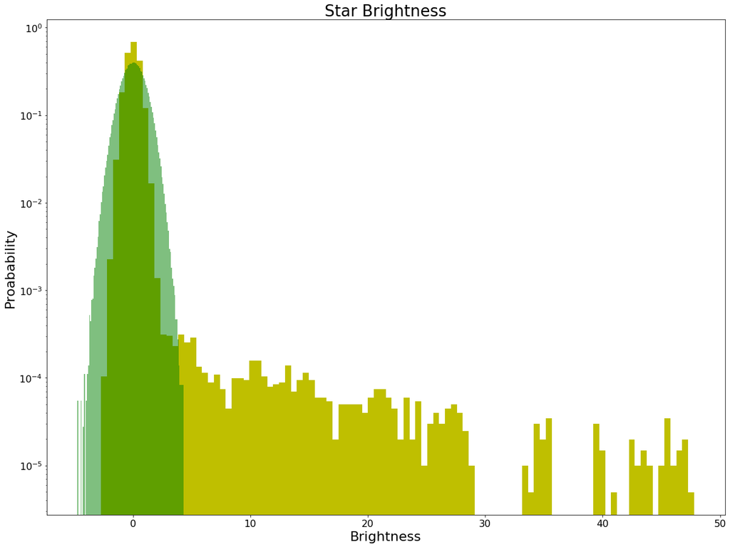

```
Highest star brightness:  47.79010819628649
```

```python
stardata = []
for i in range(10):
    for j in range(200):
        for k in range(200):
            stardata.append(data2[j,k,i])
plt.yscale('log')
plt.hist(stardata, 100, density=True, color='y')
mu = statistics.mean(stardata)
plt.tick_params(labelsize = 16)
plt.xlabel('Brightness', fontsize = 22)
plt.ylabel('Proabability', fontsize = 22)
plt.title('Star Brightness', fontsize = 26)
norm = stats.norm.rvs(mu, size=len(stardata))
plt.hist(norm, 100, density=True, color='g', alpha=.5)
plt.show()
print("Highest star brightness: ", np.max(stardata))
```

As seen in this data there is a lot of outliers in our data set. I believe that a transient star occurs at the 5 sigma probability for a standardized normal distribution. Lets calculate what this corresponds to on the brightness scale of the star.

```python
sig5 = 1 - stats.norm.cdf(5)
print("Sig 5 probability: ", sig5)
sigstar = stats.norm.ppf(1-sig5, mu)
print(mu)
print(sigstar)
```

```
Sig 5 probability:  2.866515719235352e-07
0.03344376540373896
5.522523541437977
```

I do not believe this to be completely accurate as our graph looks to be more consistent with a skewed rayleigh distribution for the brightness data. Therefore I believe a better estimate for a rare transient star would be a brightness measurement greater than 40.

We are looking for a transient, so a star that is unique and exists only in one photo image while simultaneously being really bright.

```python
uniqueStar = []

for i in range(200):
    for j in range(200):
        counter = 0
        if data2[i,j,0] > 40:
            counter = counter + 1
        if data2[i,j,1] > 40:
            counter = counter + 1
        if data2[i,j,2] > 40:
            counter = counter + 1
        if data2[i,j,3] > 40:
            counter = counter + 1
        if data2[i,j,4] > 40:
            counter = counter + 1
        if data2[i,j,5] > 40:
            counter = counter + 1
        if data2[i,j,6] > 40:
            counter = counter + 1
        if data2[i,j,7] > 40:
            counter = counter + 1
        if data2[i,j,8] > 40:
            counter = counter + 1
        if data2[i,j,9] > 40:
            counter = counter + 1
        for k in range(10):
            if(data2[i,j,k] > 40 and counter == 1):
                uniqueStar.append(data2[i,j,k])
                print(i)
                print(j)
                print(k)

print(uniqueStar)
```

```
29
24
1
[40.83313569396426]
```

#### 4)

Explain why the same data could be used for also finding the faintest stars, despite different pdfs?

The general data that was provided(10 telescopic images containing star brightness data), can be used to find both the rare super bright stars and also the faintest stars. Therefore, the data is multipurpose in that regard. The difference is in the technique needed to find the result. For me I needed to parse through each image looking for stars that fit both the criteria of being bright and rare(only occurring in one photo image). While my partner needed to find the average across the star brightness pdf.